# Module 5: Randomized Complete Block Designs (RCBD)

Designing and Analyzing an RCBD

# Designing a RCBD

## Example 5.1: Cookies in Ovens

> A bakery wants to compare three different cookie recipes for a new product line. The recipes differ in type of fat used: Classic Butter, Brown Butter, and Coconut Oil. Cookie quality is evaluated based on texture scores from a tasting panel.

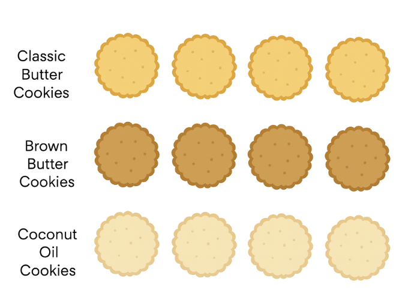

## Example 5.1: The Complication

> But…the bakery uses multiple ovens

> The ovens are known to differ slightly in temperature calibration and air circulation. These differences can affect how cookies bake. For example, some ovens may run hotter, producing crispier cookies, while others bake more slowly and yield softer cookies. Although one oven may be relatively consistent, overall consistency between ovens is unlikely.

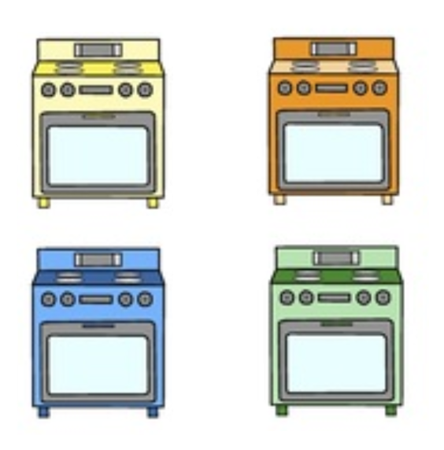

## Suppose there were *no restrictions* on recipe randomization

**Completely Randomized Design (CRD)**

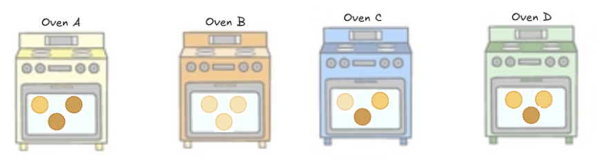

- Suppose Oven A runs slightly hotter than the others. How will this affect the results if that oven happens to get more Brown Butter trays?
- Suppose Oven B runs cooler and happens to bake most of the Coconut Oil trays. How will this affect the results?

## Where the CRD breaks down

> Key Idea: We can’t separate recipe effects from oven effects.

CRD assumes:

- Experimental units are homogeneous

But here:

- Trays within an oven are similar
- Trays across ovens are *not* similar

## The Solution: Block on oven

**Randomized Complete Block Design (RCBD)**

Why ovens? big source of variation, not scientifically interesting, known before the experiment

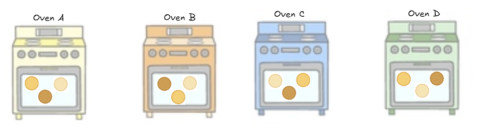

> Key Idea: Block on what you can’t control but can identify.

## What ‘Randomized Complete’ means

**Elements of a RCBD**

- **Block:** This is a homogeneous group of experimental units. A RCBD consists of first sorting the experimental units into blocks.
- **Complete:** Each block consists of one complete replication of the set of treatments. Therefore, each treatment will show up once within each block.
- **Randomized:** The treatments are randomly assigned to experimental units separately within each block.

## Why Block?

**Advantages**

- Effective blocking can lead to reduced experimental error and more precise estimates of treatment effects.
- The RCBD can accommodate any number of treatments and replications.
- The statistical analysis is relatively simple.

**Disadvantages**

- The degrees of freedom for experimental error are not as large as for a CRD.

## Example 5.1: Study Structure

**Treatment structure**

One-way treatment structure with cookie recipes (3 levels – classic butter, brown butter, and coconut oil).

**Experimental structure**

Cookie recipe treatments are randomly assigned to trays (e.u.) in a RCBD (randomized complete block design) with M = 4 blocks (or replications!) where the blocking factor is oven. The texture score is recorded for each tray (m.u.).

## Designing a RCBD

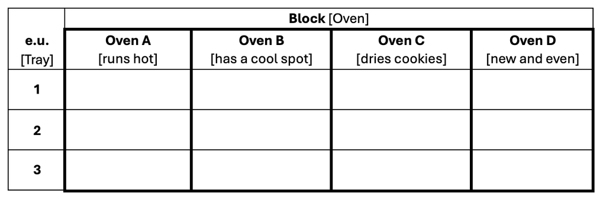

## R: Designing a RCBD with `edible` package

```r
library(tidyverse)
library(edibble)

des <- design("Cookies in Ovens") |>
  set_units(oven  = c("Oven A", "Oven B", "Oven C", "Oven D"),
            tray  = nested_in(oven, 3)) |>
  set_trts(recipe = c("Classic Butter", "Brown Butter", "Coconut Oil")) |>
  allot_trts(recipe ~ tray) |>
  assign_trts("random")

cookie_data <- serve_table(des)
cookie_data$texture <- NA
cookie_data
```

```
# Cookies in Ovens
# An edibble: 12 x 4
     oven    tray         recipe texture
   <U(4)> <U(12)>         <T(3)>
    <chr>   <chr>          <chr> <lgl>
 1 Oven A  tray01 Classic Butter NA
 2 Oven A  tray02    Coconut Oil NA
 3 Oven A  tray03   Brown Butter NA
 4 Oven B  tray04    Coconut Oil NA
 5 Oven B  tray05   Brown Butter NA
 6 Oven B  tray06 Classic Butter NA
 7 Oven C  tray07    Coconut Oil NA
 8 Oven C  tray08   Brown Butter NA
 9 Oven C  tray09 Classic Butter NA
10 Oven D  tray10    Coconut Oil NA
11 Oven D  tray11 Classic Butter NA
12 Oven D  tray12   Brown Butter NA
```

**Note**

We are going to skip the “by hand” design in R because it is a bit more complicated! But note that what is happening is that we are independently implementing a CRD within each block.

## R: Check your RCBD

**Does each oven have 3 trays?**

```r
cookie_data |>
  count(oven)
```

```
# Cookies in Ovens
# An edibble: 4 x 2
  oven       n

  <chr>  <int>
1 Oven A     3
2 Oven B     3
3 Oven C     3
4 Oven D     3
```

**Does each recipe appear r = 4 times?**

```r
cookie_data |>
  count(recipe)
```

```
# Cookies in Ovens
# An edibble: 3 x 2
  recipe             n

  <chr>          <int>
1 Brown Butter       4
2 Classic Butter     4
3 Coconut Oil        4
```

**Does each recipe appear *once* in each oven?**

```r
cookie_data |>
  count(oven, recipe)
```

```
# Cookies in Ovens
# An edibble: 12 x 3
   oven   recipe             n

   <chr>  <chr>          <int>
 1 Oven A Brown Butter       1
 2 Oven A Classic Butter     1
 3 Oven A Coconut Oil        1
 4 Oven B Brown Butter       1
 5 Oven B Classic Butter     1
 6 Oven B Coconut Oil        1
 7 Oven C Brown Butter       1
 8 Oven C Classic Butter     1
 9 Oven C Coconut Oil        1
10 Oven D Brown Butter       1
11 Oven D Classic Butter     1
12 Oven D Coconut Oil        1
```

# Analyzing a RCBD

## Example 5.1: Cookie Recipes

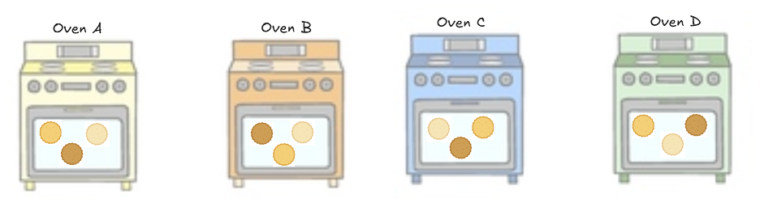

**Treatment Structure:** One-way with recipe (3-levels $t = 3$: classic butter, brown butter, coconut oil)

**Design Structure:** Recipe randomly assigned to tray (e.u.) in an RCBD with M = 4 ovens (blocking factor). Texture recorded for each tray (m.u.).

## Cookie Recipes

```r
cookie_data <- read_csv("_data/05-cookie_rcbd_data.csv")
cookie_data
```

```
# A tibble: 12 × 3
   oven  recipe         texture
   <chr> <chr>            <dbl>
 1 A     Classic Butter    80.6
 2 A     Brown Butter      84.3
 3 A     Coconut Oil       78.5
 4 B     Classic Butter    59.9
 5 B     Brown Butter      66.4
 6 B     Coconut Oil       60.7
 7 C     Classic Butter    75.1
 8 C     Brown Butter      79.9
 9 C     Coconut Oil       74.6
10 D     Classic Butter    62.5
11 D     Brown Butter      65.0
12 D     Coconut Oil       60.9
```

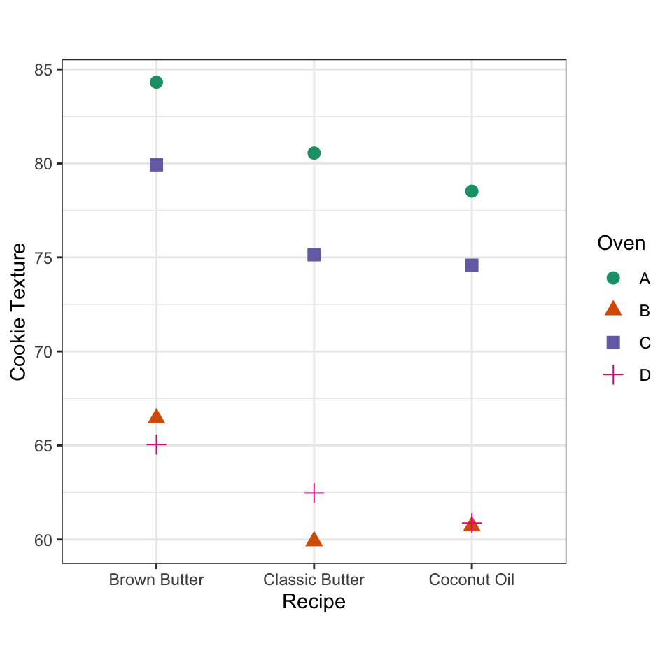

## What changes from a CRD?

If we analyze *ignoring* the effect of oven…

**Incorrect Analysis: CRD**

$y_{im} = \mu + \tau_i + \epsilon_{im} \text{ where } \epsilon_{im} \text{iid}\sim N(0,\sigma^2)$

```r
oven_crd_mod <- lm(texture ~ recipe, data = cookie_data)
anova(oven_crd_mod)
```

```
Analysis of Variance Table

Response: texture
          Df Sum Sq Mean Sq F value Pr(>F)
recipe     2  63.82  31.910  0.3459 0.7166
Residuals  9 830.24  92.248
```

## Statistical Effects Model

$$y_{ij} = \mu + \tau_i + \rho_m + \epsilon_{im} \text{ where } \epsilon_{im} \text{ iid}\sim N(0,\sigma^2)$$
for $i = 1, 2, 3$ and $m = 1, 2, 3, 4$

where:

- $y_{ij}$ is the observed texture of the cookie tray baked in the $m^{th}$ oven with the $i^{th}$ recipe.
- $\mu$ is the overall mean texture
- $\tau_i$ is the effect of the $i^{th}$ recipe
- $\rho_j$ is the effect of the $m^{th}$ oven
- $\epsilon_{ij}$ is the experimental error associated with the cookie tray baked in the $m^{th}$ oven with the $i^{th}$ recipe.

## What Blocking does to the variability

$$SST = SSTrt + SSBlk + SSE$$

- $SST = \sum_i\sum_j(y_{im}-\bar y_{\cdot\cdot})^2$
- $SSTrt = r \sum_i(\bar y_{i\cdot}-\bar y_{\cdot\cdot})^2$
- $SSBlk = t\sum_j(\bar y_{\cdot m}-\bar y_{\cdot\cdot})^2$
- $SSE = t\sum_j(y_{ij}-\bar y_{i\cdot} - \bar y_{\cdot m} + \bar y_{\cdot\cdot})^2$

## ANOVA Table

| Source of Variation | DF | SS | MS | F |
| --- | --- | --- | --- | --- |
| Block | r - 1 | SSBlk | MSBlk | MSBlk/MSE |
| Treatment | t - 1 | SSTrt | MSTrt | MSTrt/MSE |
| Block x Treatment $\rightarrow$ error | (M - 1)(t - 1) | SSE | MSE $\rightarrow \sigma^2$ |  |
| **Total (N = M$\times$ t)** | **N - 1** | SST |  |  |

> Blocking is a *design tool*, not usually a research question.

## Skeleton ANOVA

| Source of Variation | DF |
| --- | --- |

## R: RCBD Analysis

```r
options(contrasts = c("contr.sum", "contr.poly"))
oven_rcbd_mod <- lm(texture ~ recipe + oven, data = cookie_data)
anova(oven_rcbd_mod)
```

```
Analysis of Variance Table

Response: texture
          Df Sum Sq Mean Sq F value    Pr(>F)
recipe     2  63.82  31.910  38.607 0.0003749 ***
oven       3 825.28 275.092 332.829 4.651e-07 ***
Residuals  6   4.96   0.827
---
Signif. codes:  0 '***' 0.001 '**' 0.01 '*' 0.05 '.' 0.1 ' ' 1
```

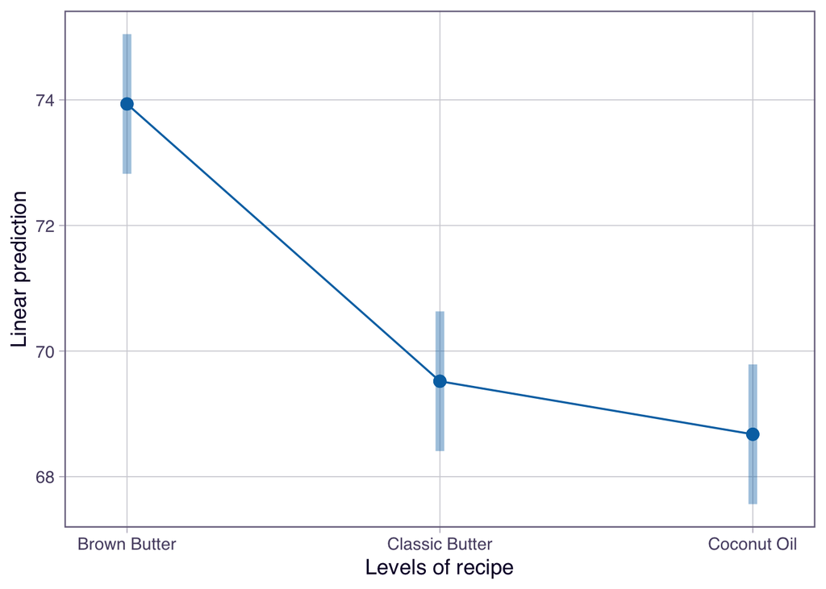

```r
emmip(oven_rcbd_mod, ~ recipe, CI = T)
```

```r
emmeans(oven_rcbd_mod, ~ recipe) |>
  cld(Letters = LETTERS, decreasing = T, adjust = "tukey")
```

```
 recipe         emmean    SE df lower.CL upper.CL .group
 Brown Butter     73.9 0.455  6     72.4     75.4  A
 Classic Butter   69.5 0.455  6     68.0     71.0   B
 Coconut Oil      68.7 0.455  6     67.2     70.2   B

Results are averaged over the levels of: oven
Confidence level used: 0.95
Conf-level adjustment: sidak method for 3 estimates
P value adjustment: tukey method for comparing a family of 3 estimates
significance level used: alpha = 0.05
NOTE: If two or more means share the same grouping symbol,
      then we cannot show them to be different.
      But we also did not show them to be the same.
```

## Check Model Assumptions – $\epsilon_{im} \text{iid} \sim N(0,\sigma^2)$

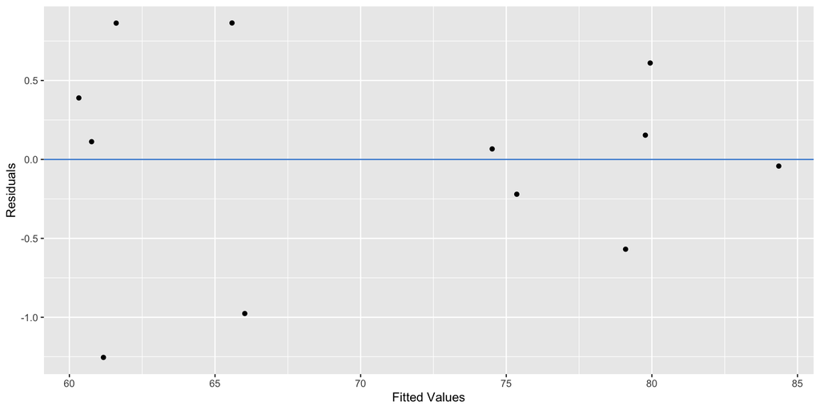

```r
oven_rcbd_mod |>
  broom::augment() |>
  ggplot(aes(x = .fitted, y = .resid)) +
  geom_point() +
  geom_hline(yintercept = 0,
             color = "#3a86d4") +
  labs(x = "Fitted Values", y = "Residuals")
```

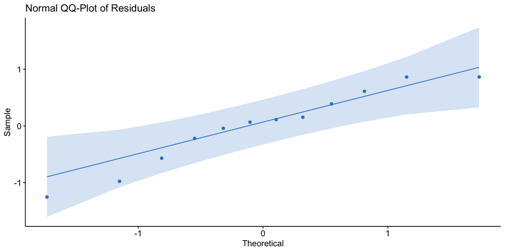

```r
oven_rcbd_mod |>
  broom::augment() |>
  ggpubr::ggqqplot(x = ".resid",
         color = "#3a86d4") +
  labs(title = "Normal QQ-Plot of Residuals")
```

## RCBD vs CRD

If we ignore ovens (CRD):

- Oven variability inflates MSE
- Harder to detect recipe differences

```
Analysis of Variance Table

Response: texture
          Df Sum Sq Mean Sq F value Pr(>F)
recipe     2  63.82  31.910  0.3459 0.7166
Residuals  9 830.24  92.248
```

With RCBD:

- Oven variability is removed from error
- Smaller MSE
- More power *(if blocks are different)*

```
Analysis of Variance Table

Response: texture
          Df Sum Sq Mean Sq F value    Pr(>F)
recipe     2  63.82  31.910  38.607 0.0003749 ***
oven       3 825.28 275.092 332.829 4.651e-07 ***
Residuals  6   4.96   0.827
---
Signif. codes:  0 '***' 0.001 '**' 0.01 '*' 0.05 '.' 0.1 ' ' 1
```

## Why is this model additive? (no interaction)

- Each recipe appears *once* per oven
- No replication within recipe-oven combinations
- Interaction is not estimable

> Recall: The experimental error comes from the block x treatment term.

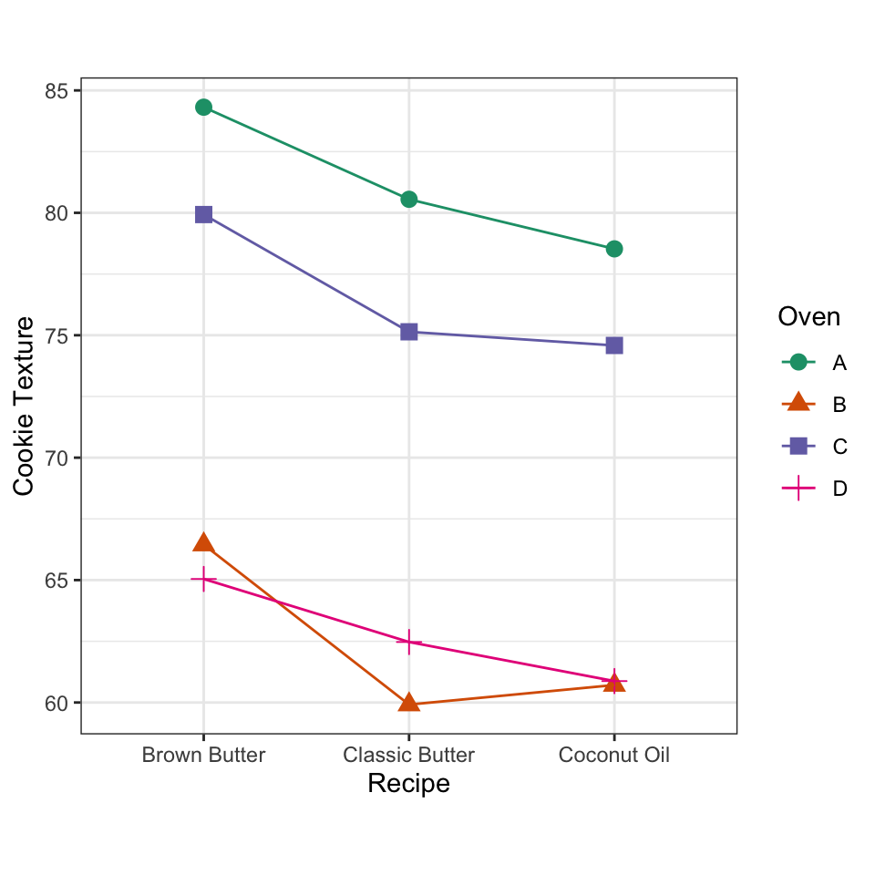